# COVID Data

Gabrielle Olinger

2026-02-26

```r
library(tidyverse)
library(lubridate)
```

## Motivation

The COVID-19 pandemic, first identified in Wuhan and later declared a global pandemic by the World Health Organization, affected countries in dramatically different ways over time. Data analyses of COVID cases are important in understanding how and why infection spreads. Evaluating global data helps to illustrate not just the impact of COVID but also to compare cases in the context of differing government policies. Some nations implemented strict lockdowns, border closures, and aggressive testing and tracing, while others relied on more relaxed restrictions or prioritized economic continuity. By analyzing COVID-19 case trends over time by country, this project enables comparison of how these differing policy approaches influenced overall outcomes, offering valuable insights for designing more effective responses to future global health crises.

## Importing Data

```r
url_in = "https://raw.githubusercontent.com/CSSEGISandData/COVID-19/master/csse_covid_19_data/csse_covid_19_time_series/"

file_names <- c("time_series_covid19_confirmed_US.csv",  "time_series_covid19_confirmed_global.csv", "time_series_covid19_deaths_US.csv",  "time_series_covid19_deaths_global.csv")

# concatenate
urls <- str_c(url_in, file_names)
```

```r
US_cases_untidy <- read_csv(urls[1])
global_cases_untidy <- read_csv(urls[2])
US_deaths_untidy <- read_csv(urls[3])
global_deaths_untidy <- read_csv(urls[4])
```

## Tidying Data

I need to pivot the datasets so dates are no longer columns. I will not be using Lat and Long in the analysis, so I will remove these columns. I rename ‘Country/Region’ and ‘Province/State’ to be more R friendly, and I change dates to the appropriate format. In order to streamline the analysis, I will merge the cases dataset and the deaths dataset together.

I will tidy global data first:

```r
# pivot, remove variables not of interest, and reformat date
global_cases <- global_cases_untidy %>%
  pivot_longer(cols = -c('Province/State', 'Country/Region', Lat, Long), names_to = "date", values_to = "cases") %>%
  select(-c(Lat,Long)) %>%
  mutate(date = mdy(date))

# repeat for the deaths dataset
global_deaths <- global_deaths_untidy %>%
  pivot_longer(cols = -c('Province/State', 'Country/Region', Lat, Long), names_to = "date", values_to = "deaths") %>%
  select(-c(Lat,Long)) %>%
  mutate(date = mdy(date))

# merge the datasets
global <- global_cases %>%
          full_join(global_deaths) %>%
          rename(Country_Region = 'Country/Region',
                 Province_State = 'Province/State')
```

```r
unique(global$Country_Region)
```

```
##   [1] "Afghanistan"                      "Albania"
##   [3] "Algeria"                          "Andorra"
##   [5] "Angola"                           "Antarctica"
##   [7] "Antigua and Barbuda"              "Argentina"
##   [9] "Armenia"                          "Australia"
##  [11] "Austria"                          "Azerbaijan"
##  [13] "Bahamas"                          "Bahrain"
##  [15] "Bangladesh"                       "Barbados"
##  [17] "Belarus"                          "Belgium"
##  [19] "Belize"                           "Benin"
##  [21] "Bhutan"                           "Bolivia"
##  [23] "Bosnia and Herzegovina"           "Botswana"
##  [25] "Brazil"                           "Brunei"
##  [27] "Bulgaria"                         "Burkina Faso"
##  [29] "Burma"                            "Burundi"
```

[output cut: 86 more lines]

I want to focus specifically on countries/regions, so I am going to remove rows labeled “Summer Olympics 2020” and “Winter Olympics 2022.” Also, Diamond Princess and MS Zaandam are cruise ships.

```r
regions_to_remove <- c("Summer Olympics 2020", "Winter Olympics 2022", "Diamond Princess", "MS Zaandam")
global <- global %>%
  filter(!(Country_Region %in% regions_to_remove))
```

Now I will tidy US data:

```r
US_cases <- US_cases_untidy %>%
    pivot_longer(cols = -(UID:Combined_Key),
                 names_to = "date",
                 values_to = "cases") %>%
  select(Admin2:cases) %>%
  mutate(date = mdy(date)) %>%
  select(-c(Lat,Long_))

US_deaths <- US_deaths_untidy %>%
    pivot_longer(cols = -(UID:Population),
                 names_to = "date",
                 values_to = "deaths") %>%
  select(Admin2:deaths) %>%
  mutate(date = mdy(date)) %>%
  select(-c(Lat,Long_))

US <- US_cases %>% full_join(US_deaths)
```

[output not shown]

I need to do some tidying so that the US and global data are comparable. First I will add a “Combined Key” column in the global data that combines the Country_Region and Province_State columns. The death dataset for the US included population, so I will also add population to the global data set.

Note that if the Province_State is NA, the Combined_Key is equivalent to Country_Region.

```r
global <- global %>% unite("Combined_Key",
                           c(Province_State, Country_Region),
                           sep = ",",
                           na.rm = TRUE,
                           remove = FALSE)
```

Below I add population data. This comes from the same data repository described above.

```r
uid_lookup_url = "https://raw.githubusercontent.com/CSSEGISandData/COVID-19/refs/heads/master/csse_covid_19_data/UID_ISO_FIPS_LookUp_Table.csv"

uid <- read_csv(uid_lookup_url) %>% select(-c(Lat, Long_, Combined_Key, code3, iso2, iso3, Admin2))
global <- global %>%
    left_join(uid, by = c("Province_State", "Country_Region")) %>%
    select(-c(UID, FIPS)) %>%
    select(Province_State, Country_Region, date,
           cases, deaths, Population, Combined_Key)
```

### Summaries

```r
summary(US)
```

```
##     Admin2          Province_State     Country_Region     Combined_Key
##  Length:3819906     Length:3819906     Length:3819906     Length:3819906
##  Class :character   Class :character   Class :character   Class :character
##  Mode  :character   Mode  :character   Mode  :character   Mode  :character
##
##
##
##       date                cases           Population           deaths
##  Min.   :2020-01-22   Min.   :  -3073   Min.   :       0   Min.   :  -82.0
##  1st Qu.:2020-11-02   1st Qu.:    330   1st Qu.:    9917   1st Qu.:    4.0
##  Median :2021-08-15   Median :   2272   Median :   24892   Median :   37.0
##  Mean   :2021-08-15   Mean   :  14088   Mean   :   99604   Mean   :  186.9
##  3rd Qu.:2022-05-28   3rd Qu.:   8159   3rd Qu.:   64979   3rd Qu.:  122.0
##  Max.   :2023-03-09   Max.   :3710586   Max.   :10039107   Max.   :35545.0
```

```r
summary(global)
```

```
##  Province_State     Country_Region          date                cases
##  Length:325755      Length:325755      Min.   :2020-01-22   Min.   :        0
##  Class :character   Class :character   1st Qu.:2020-11-02   1st Qu.:      751
##  Mode  :character   Mode  :character   Median :2021-08-15   Median :    15385
##                                        Mean   :2021-08-15   Mean   :   972844
##                                        3rd Qu.:2022-05-28   3rd Qu.:   235781
##                                        Max.   :2023-03-09   Max.   :103802702
##
##      deaths          Population        Combined_Key
##  Min.   :      0   Min.   :6.700e+01   Length:325755
##  1st Qu.:      4   1st Qu.:5.790e+05   Class :character
##  Median :    161   Median :6.574e+06   Mode  :character
##  Mean   :  13568   Mean   :2.769e+07
##  3rd Qu.:   3138   3rd Qu.:2.642e+07
##  Max.   :1123836   Max.   :1.380e+09
##                    NA's   :5715
```

```r
na_pop <- global %>% filter(is.na(Population))
unique(na_pop$Combined_Key)
```

```
## [1] "Antarctica"                    "Diamond Princess,Canada"
## [3] "Grand Princess,Canada"         "Repatriated Travellers,Canada"
## [5] "Unknown,China"
```

For the purposes of this analysis, I am going to remove areas where population data is NA.

```r
global <- global %>%
  filter(!is.na(Population))
```

## Visualization

```r
theme_set(theme_minimal())
```

I first want to look at how the total number of cases in a country compares to that country’s population.

```r
global_totals <- global %>%
  group_by(Country_Region) %>%
  summarize(
    total_cases = max(cases, na.rm = TRUE),
    total_deaths = max(deaths, na.rm = TRUE),
    Population = max(Population, na.rm = TRUE)
  )%>%
  ungroup()
```

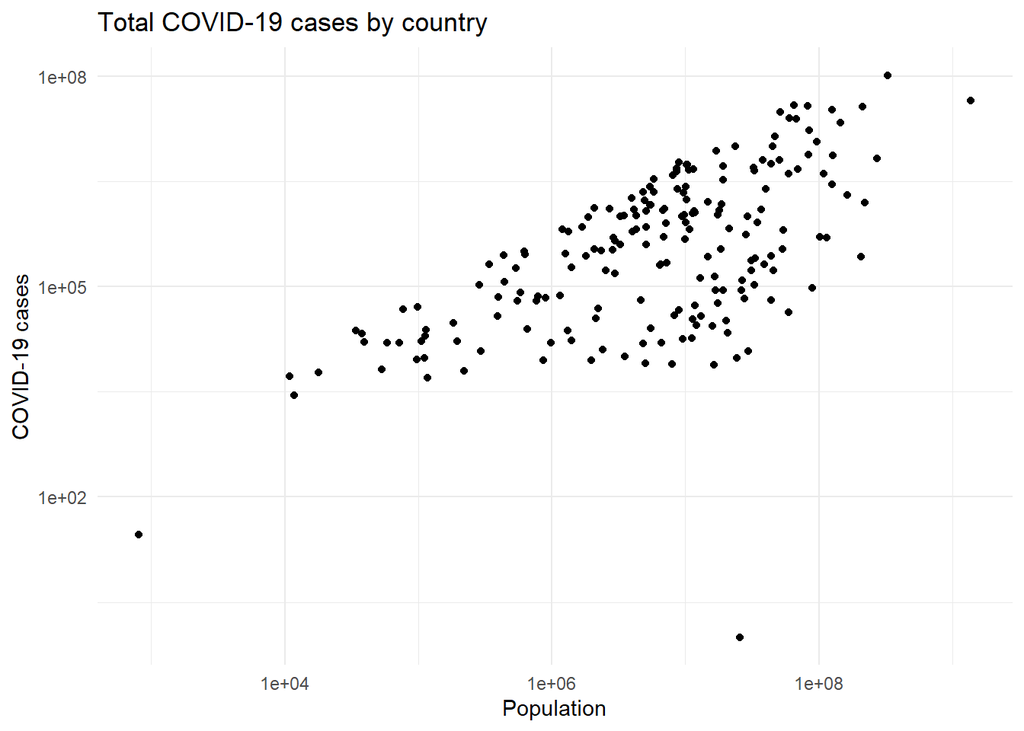

```r
global_totals %>% ggplot()+
  geom_point(aes(x = Population, y = total_cases))+
  scale_y_log10()+
  scale_x_log10()+
  labs(y = 'COVID-19 cases', title = 'Total COVID-19 cases by country')
```

### Analysis

Note that both the x and y axis have log scales. It appears that number of cases and population follows a power law relationship. Though this visualization proves no causality, this makes sense intuitively; the more people in a country, the more people likely to get infected. A small country has a smaller pool of people able to get sick. There’s also a few outliers. The most jarring is the one displaying a large population but a low amount cases. Let’s see what country this is:

```r
global_totals %>% slice_min(total_cases)
```

```
## # A tibble: 1 × 4
##   Country_Region total_cases total_deaths Population
##   <chr>                <dbl>        <dbl>      <dbl>
## 1 Korea, North             1            6   25778815
```

This outlier seems to be the result of reporting errors. It appears that North Korea only reported one case, and, even stranger, six deaths. Obviously this is not possible. North Korea’s isolationist policies may contribute to errors in reporting.

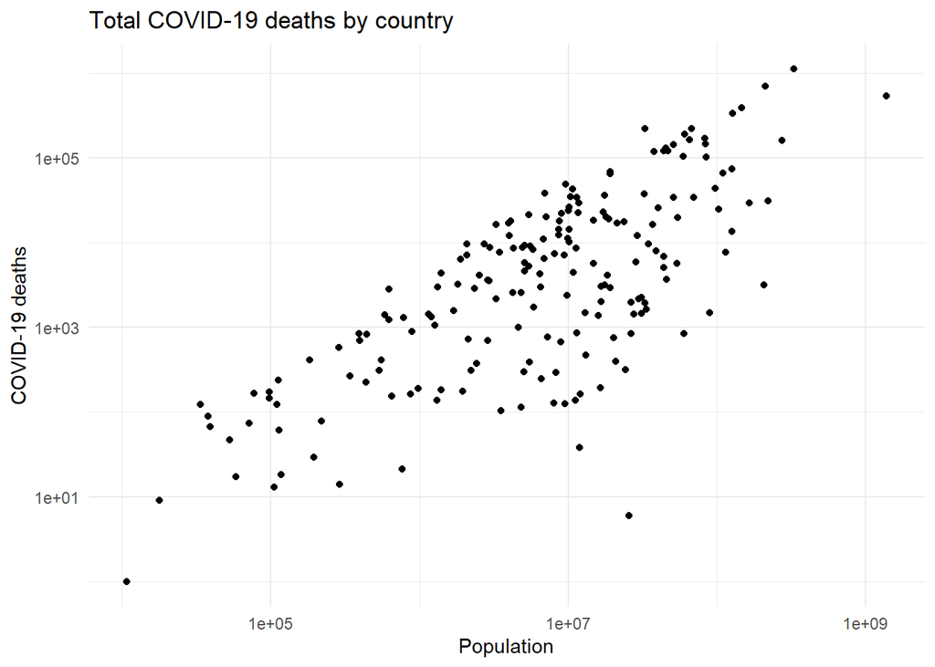

```r
global_totals %>%
  filter(total_deaths>0) %>%
  ggplot()+
  geom_point(aes(x = Population, y = total_deaths))+
  scale_y_log10()+
  scale_x_log10()+
  labs(y = 'COVID-19 deaths', title = "Total COVID-19 deaths by country")
```

### Analysis

This seems to follow a similar power law. This again makes sense intuitively; the greater population, the greater number of cases, and thus the greater number of deaths. Both this visualization and the one above demonstrate a “blob” at the center, indicating that total cases and deaths varied among medium sized countries. This could be due to anything from quarantine policy differences to population density. There appears to be a lot of data points with a low amount of deaths, so I investigate this further below.

```r
global_totals %>% slice_min(total_deaths, n = 10)
```

```
## # A tibble: 10 × 4
##    Country_Region   total_cases total_deaths Population
##    <chr>                  <dbl>        <dbl>      <dbl>
##  1 Holy See                  29            0        809
##  2 Tuvalu                  2828            0      11792
##  3 Nauru                   5247            1      10834
##  4 Korea, North               1            6   25778815
##  5 Palau                   5991            9      18008
##  6 Tonga                  16810           13     105697
##  7 Vanuatu                12014           14     292680
##  8 Marshall Islands       15649           17      58413
##  9 Kiribati                5014           18     117606
## 10 Bhutan                 62627           21     771612
```

There are a couple data points that seem dubious. For example, it seems a bit unrealistic that the Marshall Islands had upwards of 15,000 cases but only 17 deaths. This could be the result of inconsistency or errors in reporting.

## Question of Interest

**How does the COVID-19 death rate (no. of deaths divided by no. of cases) vary with population density?**

In order to answer this question, I will need to import supplementary population density data.

This global population density data is provided by World Development Indicators, which is operated by the World Bank Group and is the primary World Bank collection of development indicators, complied from officially recognized international sources. Population density is listed as people per square kilometer of land area. I will be using the mid-year population densities collected in 2022. From the data source:

> Population is based on the de facto definition of population, which counts all residents regardless of legal status or citizenship–except for refugees not permanently settled in the country of asylum, who are generally considered part of the population of their country of origin. Land area is a country’s total area, excluding area under inland water bodies, national claims to continental shelf, and exclusive economic zones. In most cases the definition of inland water bodies includes major rivers and lakes.

```r
global_densities_untidy <- read_csv("https://raw.githubusercontent.com/gabbyoln/DTSA5301-Projects/refs/heads/main/data/global_population_density.csv")
# tidying the data
global_densities <- global_densities_untidy %>%
  select("Country Name", "2022") %>%
  rename(Country_Region = 'Country Name',
         pop_density = '2022')
```

```r
# remap some country names so that the two data sets match
global_densities <- global_densities %>%
  mutate(Country_Region = recode(Country_Region,
                                 'Bahamas, The' = 'Bahamas',
                                 'Brunei Darussalam' = 'Brunei',
                                 'Myanmar' = 'Burma',
                                 'Congo, Rep.' = 'Congo (Brazzaville)',
                                 'Congo, Dem. Rep.' = 'Congo (Kinshasa)',
                                 'Egypt, Arab Rep.' = 'Egypt',
                                 'Iran, Islamic Rep.' = 'Iran',
                                 'Gambia, The' = 'Gambia',
                                 "Korea, Dem. People's Rep." = "Korea, North",
                                 "Korea, Rep." = 'Korea, South',
                                 'Kyrgyz Republic' = 'Kyrgyzstan',
                                 'Lao PDR' = 'Laos',
                                 'Micronesia, Fed. Sts.' = 'Micronesia',
                                 'Russian Federation' = 'Russia',
                                 'St. Kitts and Nevis' = 'Saint Kitts and Nevis',
                                 'St. Lucia' = 'Saint Lucia',
                                 'St. Vincent and the Grenadines' = 'Saint Vincent and the Grenadines',
                                 'Slovak Republic' = 'Slovakia',
                                 'Somalia, Fed. Rep.' = 'Somalia',
                                 'Syrian Arab Republic' = 'Syria',
                                 'Turkiye' = 'Turkey',
                                 'United States' = 'US',
                                 'Venezuela, RB' = 'Venezuela',
                                 'Viet Nam' = 'Vietnam',
                                 'Yemen, Rep.' = 'Yemen'
                                 ))
```

I will exclude North Korea for the reasons listed above. I will also exclude Holy See (the Vatican), Taiwan, and Kosovo, because there is no population density data for these areas.

```r
global_totals_new <- global_totals %>%
  left_join(global_densities, by = 'Country_Region') %>%
  filter(!(Country_Region %in% c('Holy See', 'Kosovo', 'Taiwan*', 'Korea, North')
           ))%>%
  filter(total_deaths>0)%>%
  mutate(death_rate = total_deaths/total_cases,
         log_pop_dens = log(pop_density),
         log_death_rate = log(death_rate))
```

## Model

I will attempt to model the COVID-19 death rate (total number of deaths divided by total number of cases) across countries as a function of population density. I model the two variables using a relationship of the form $ln(y) = b\cdot ln(x)+a$. This is equivalent to the expression $y = a\cdot x^b$.

```r
mod <- lm(log_death_rate ~ log_pop_dens, data = global_totals_new)
summary(mod)
```

```
##
## Call:
## lm(formula = log_death_rate ~ log_pop_dens, data = global_totals_new)
##
## Residuals:
##     Min      1Q  Median      3Q     Max
## -3.5641 -0.5372  0.0842  0.7392  2.9601
##
## Coefficients:
##              Estimate Std. Error t value Pr(>|t|)
## (Intercept)  -3.99601    0.24210 -16.505   <2e-16 ***
## log_pop_dens -0.15757    0.05223  -3.017   0.0029 **
## ---
## Signif. codes:  0 '***' 0.001 '**' 0.01 '*' 0.05 '.' 0.1 ' ' 1
##
## Residual standard error: 1.008 on 189 degrees of freedom
## Multiple R-squared:  0.04595,    Adjusted R-squared:  0.0409
## F-statistic: 9.102 on 1 and 189 DF,  p-value: 0.002904
```

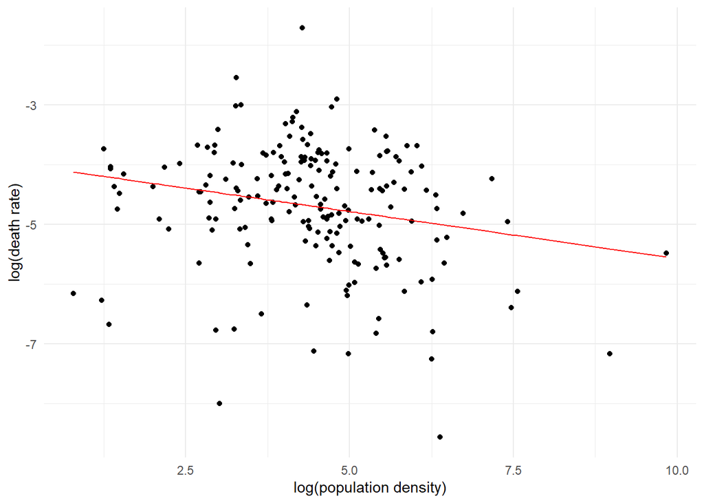

```r
global_totals_new %>%
  mutate(pred = predict(mod)) %>%
  ggplot() +
  geom_point(aes(x = log_pop_dens, y = log_death_rate))+
  geom_line(aes(x = log_pop_dens, y = pred),color = 'red')+
  labs(x = 'log(population density)', y = 'log(death rate)')
```

```r
median(global_totals_new$death_rate)
```

```
## [1] 0.01075774
```

## Bias and Sources of Error

Some countries may have unreliable data, such as North Korea reporting only one case. This reporting bias reflects a broader issue that the reliability of data in certain regions can be compromised by political tensions or international policy. Countries with greater resources and more centralized reporting methods are biased towards reporting higher numbers of cases. In contrast, countries with fewer resources may be subject to reporting bias, where not all cases are recorded.

There may also be measurement bias. While COVID-19 cases are easier to tally, deaths can be more subjective; for instance, if someone dies of COVID-related pneumonia, is the cause of death listed as COVID or pneumonia? Therefore, when evaluating the extent of COVID across different countries/regions, cases may be a more reliable measure than deaths.